# Exam 01 Review

2019-10-09

```r
library(tidyverse)
library(broom)
library(rms)
library(knitr)
library(cowplot)
```

## Introduction

This data set contains various characteristics and price information for 191 vehicles. The data are from the *1985 Model Import Car and Truck Specifications* and the *1985 Ward’s Automotive Yearbook.*

We’ll use the following variables for this review:

- `price`: selling price (U.S. dollars)
- `length`: length of vehicle (inches)
- `horsepower`: units measuring the engine power
- `highway`: highway mileage (miles per gallon)
- `body_style`: style of vehicle (convertible, hardtop, hatchback, sedan, wagon)
- `fuel_type`: fuel required for vehicle (diesel, gas)

```r
auto <- read_csv("data/auto.csv") %>%
  mutate(horsepowerCent = horsepower - mean(horsepower),
         lengthCent = length - mean(length),
         highwayCent = highway_mpg - mean(highway_mpg))
```

## Part 1: Analysis of Variance

```r
anova <- aov(price ~ body_style, data = auto)
kable(tidy(anova),digits = 3)
```

| term | df | sumsq | meansq | statistic | p.value |
| --- | --- | --- | --- | --- | --- |
| body_style | 4 | 1930563714 | 482640929 | 8.933 | 0 |
| Residuals | 186 | 10049377041 | 54028909 | NA | NA |

1. Using the ANOVA table, how many body styles are in the `auto` dataset?
2. What is the estimated variance of the distribution of price within each type of body style?
3. State the null and alternative hypotheses for the test conducted in the ANOVA table.
4. Briefly explain how the test statistic, 8.933, is calculated.
5. State your conclusion for the test in (3) in the context of the data.
6. Briefly describe the next steps you would take in the analysis.

## Part 2: Original Model

```r
m0 <-lm(price ~ horsepowerCent + highwayCent + lengthCent + body_style + fuel_type,
        data = auto)
kable(tidy(m0, conf.int = TRUE), round=3)
```

| term | estimate | std.error | statistic | p.value | conf.low | conf.high |
| --- | --- | --- | --- | --- | --- | --- |
| (Intercept) | 22903.73495 | 1827.96554 | 12.5296317 | 0.0000000 | 19297.00525 | 26510.4646 |
| horsepowerCent | 130.77585 | 14.40730 | 9.0770514 | 0.0000000 | 102.34902 | 159.2027 |
| highwayCent | -32.15625 | 93.58459 | -0.3436063 | 0.7315390 | -216.80652 | 152.4940 |
| lengthCent | 185.55219 | 44.10914 | 4.2066609 | 0.0000406 | 98.52115 | 272.5832 |
| body_stylehardtop | -2763.88352 | 2096.83835 | -1.3181195 | 0.1891202 | -6901.12187 | 1373.3548 |
| body_stylehatchback | -6715.58547 | 1676.63201 | -4.0054022 | 0.0000901 | -10023.72138 | -3407.4496 |
| body_stylesedan | -5682.83489 | 1724.45807 | -3.2954323 | 0.0011813 | -9085.33565 | -2280.3341 |
| body_stylewagon | -7417.17506 | 1885.15358 | -3.9345203 | 0.0001185 | -11136.74157 | -3697.6085 |
| fuel_typegas | -4175.15600 | 1096.45617 | -3.8078640 | 0.0001915 | -6338.55621 | -2011.7558 |

1. What is the primary advantage of using horsepowerCent, highwayCent, and lengthCent in the model instead of the original variables (highway, horsepower, and length)?
2. Suppose you fit a new model that includes horsepower instead of horsepowerCent as a predictor. All other predictors remain the same as in the model output above. Briefly describe how the estimate of the coefficient of horsepower, the corresponding test statistic, and the corresponding p-value would compare to those shown in the model output above.
3. What are the assumptions of multiple linear regression?
4. Some of the residuals plots used to check the model assumptions are shown below. For each plot,
   - State the assumption(s) that can be assessed using that plot.
   - Use the plot to determine if the assumption is satisfied.

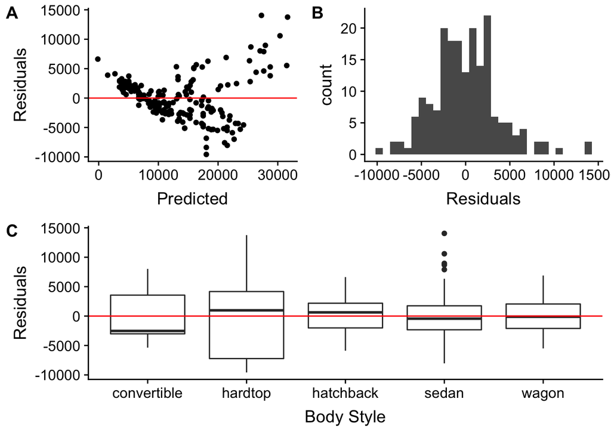

```r
m0_aug = augment(m0)
p1 <- ggplot(data = m0_aug, aes(x = .fitted, y = .resid)) +
  geom_point() +
  geom_hline(yintercept = 0, color = "red") +
  labs(x = "Predicted", y = "Residuals")

p2 <- ggplot(data = m0_aug, aes(x = .resid)) +
  geom_histogram() +
  labs(x = "Residuals")

p3<- ggplot(data = m0_aug, aes(x = body_style, y = .resid)) +
  geom_boxplot() +
  geom_hline(yintercept = 0, color = "red") +
  labs(x = "Body Style", y = "Residuals")

top_row <- plot_grid(p1, p2, ncol = 2, labels = c("A", "B"))
plot_grid(top_row, p3, nrow = 2, labels = c("", "C"))
```

### Part 3: Model with Log-Transformed Price

```r
auto <- auto %>%
  mutate(logprice = log(price))
```

```r
m1 <- lm(logprice ~ horsepowerCent + highwayCent + lengthCent + body_style + fuel_type +
           horsepowerCent*body_style,data=auto)
kable(tidy(m1, conf.int = TRUE), digits = 3)
```

| term | estimate | std.error | statistic | p.value | conf.low | conf.high |
| --- | --- | --- | --- | --- | --- | --- |
| (Intercept) | 9.958 | 0.099 | 100.881 | 0.000 | 9.763 | 10.152 |
| horsepowerCent | 0.009 | 0.002 | 5.027 | 0.000 | 0.006 | 0.013 |
| highwayCent | -0.011 | 0.004 | -2.572 | 0.011 | -0.020 | -0.003 |
| lengthCent | 0.014 | 0.002 | 6.623 | 0.000 | 0.010 | 0.018 |
| body_stylehardtop | -0.371 | 0.120 | -3.085 | 0.002 | -0.609 | -0.134 |
| body_stylehatchback | -0.359 | 0.092 | -3.890 | 0.000 | -0.541 | -0.177 |
| body_stylesedan | -0.296 | 0.093 | -3.170 | 0.002 | -0.480 | -0.112 |
| body_stylewagon | -0.401 | 0.099 | -4.068 | 0.000 | -0.595 | -0.206 |
| fuel_typegas | -0.328 | 0.051 | -6.457 | 0.000 | -0.429 | -0.228 |
| horsepowerCent:body_stylehardtop | 0.002 | 0.002 | 0.689 | 0.491 | -0.003 | 0.006 |
| horsepowerCent:body_stylehatchback | -0.003 | 0.002 | -1.760 | 0.080 | -0.007 | 0.000 |
| horsepowerCent:body_stylesedan | -0.001 | 0.002 | -0.559 | 0.577 | -0.005 | 0.003 |
| horsepowerCent:body_stylewagon | -0.004 | 0.002 | -1.781 | 0.077 | -0.008 | 0.000 |

1. Describe the subset of cars that are expected to have a median price of exp(9.958) = $21,110.51.
2. Interpret the estimated coefficient of `lengthCent` in terms of the **price**.
3. Describe the difference in the typical price of cars that are gas fueled versus those that are diesel fueled, holding all else constant.
4. What is the estimated slope of `horsepowerCent` for a convertible?
5. What is the estimated slope of `horsepowerCent` for a hatchback?

## Part 4: Assessing the Model

Summary statistics for the model are shown below.

```r
glance(m1)
```

```
## # A tibble: 1 x 11
##   r.squared adj.r.squared sigma statistic  p.value    df logLik   AIC   BIC
##       <dbl>         <dbl> <dbl>     <dbl>    <dbl> <int>  <dbl> <dbl> <dbl>
## 1     0.890         0.882 0.173      119. 2.12e-78    13   70.9 -114. -68.2
## # … with 2 more variables: deviance <dbl>, df.residual <int>
```

1. What is the estimated regression variance?
2. Compare $R^2$ and $Adj. R^2$. What does this comparison tell you about the predictors in the model?
3. The VIF for this model is calculated below. Based on the values of VIF, what is a potential concern with this model?

```r
vif(m1)
```

```
##                     horsepowerCent                        highwayCent
##                          27.769092                           5.067945
##                         lengthCent                  body_stylehardtop
##                           4.046363                           3.711303
##                body_stylehatchback                    body_stylesedan
##                          11.901157                          13.846868
##                    body_stylewagon                       fuel_typegas
##                           6.814900                           1.479830
##   horsepowerCent:body_stylehardtop horsepowerCent:body_stylehatchback
##                           4.976523                          10.415524
##     horsepowerCent:body_stylesedan     horsepowerCent:body_stylewagon
##                          13.162600                           3.233575
```